# Presentation

Ying Zhu

11/1/2016

### Baseline model

When finding the best model of baseline, we have a lot of try.

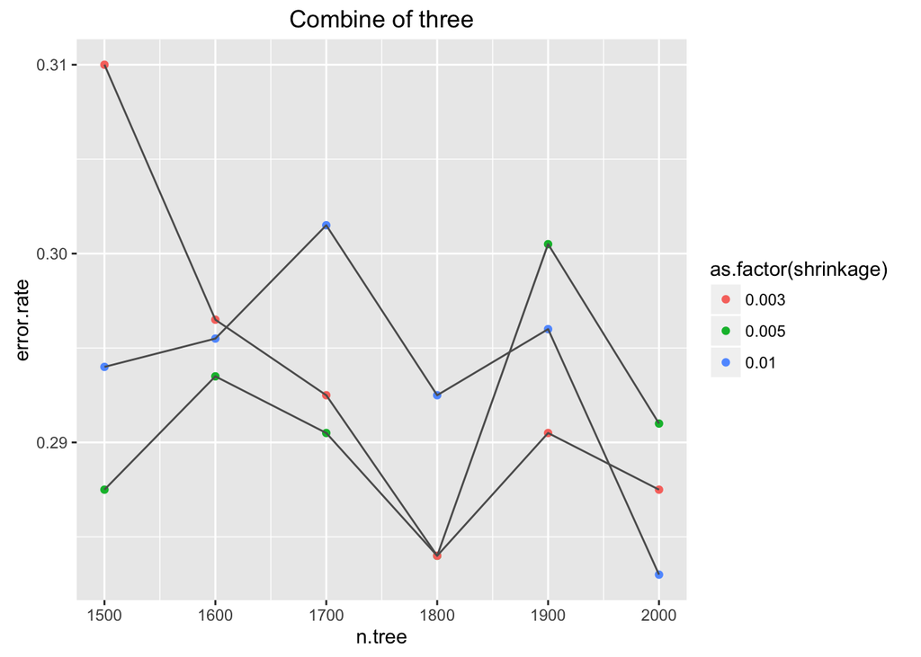

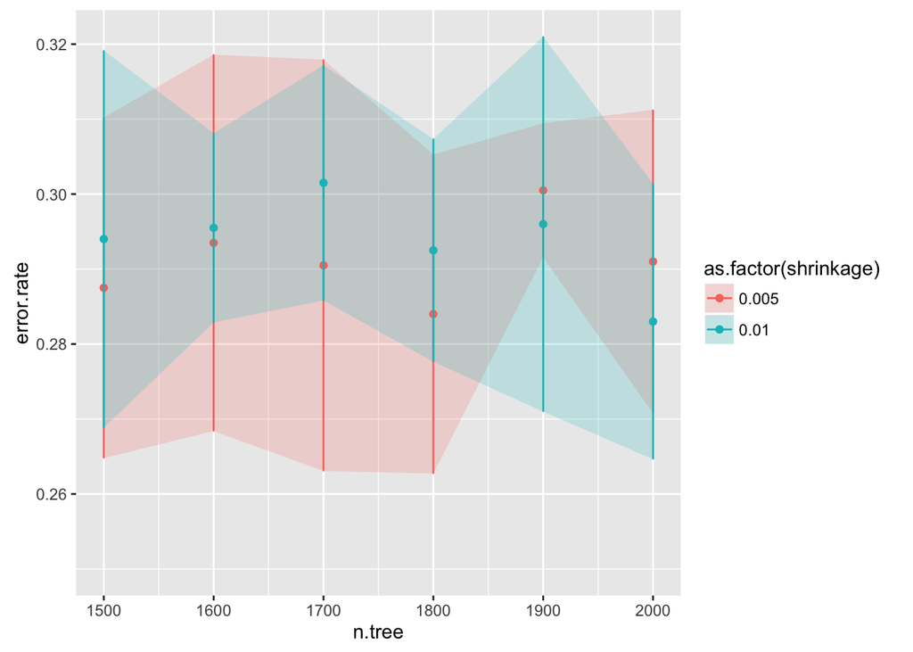

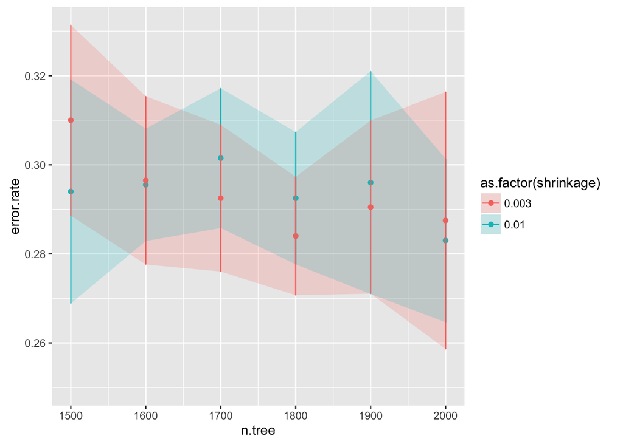

```
##    n.tree error.rate         sd shrinkage
## 1    1500     0.2875 0.02592000     0.005
## 2    1600     0.2935 0.02864655     0.005
## 3    1700     0.2905 0.03130000     0.005
## 4    1800     0.2840 0.02427705     0.005
## 5    1900     0.3005 0.01021641     0.005
## 6    2000     0.2910 0.02308950     0.005
## 7    1500     0.2940 0.02870100     0.010
## 8    1600     0.2955 0.01440000     0.010
## 9    1700     0.3015 0.01790600     0.010
## 10   1800     0.2925 0.01695582     0.010
## 11   1900     0.2960 0.02853726     0.010
## 12   2000     0.2830 0.02094914     0.010
## 13   1500     0.3100 0.02443103     0.003
## 14   1600     0.2965 0.02154936     0.003
## 15   1700     0.2925 0.01879162     0.003
## 16   1800     0.2840 0.01516575     0.003
## 17   1900     0.2905 0.02217826     0.003
## 18   2000     0.2875 0.03292985     0.003
```

Based on the picture, we choose n.tree=1800, shringkage=0.003 to fit our baseline model.

### what we have tried

```
## [1] "mean error"     "0.331709083355"
```

```
## [1] "minimal error" "0.3021002189"
```

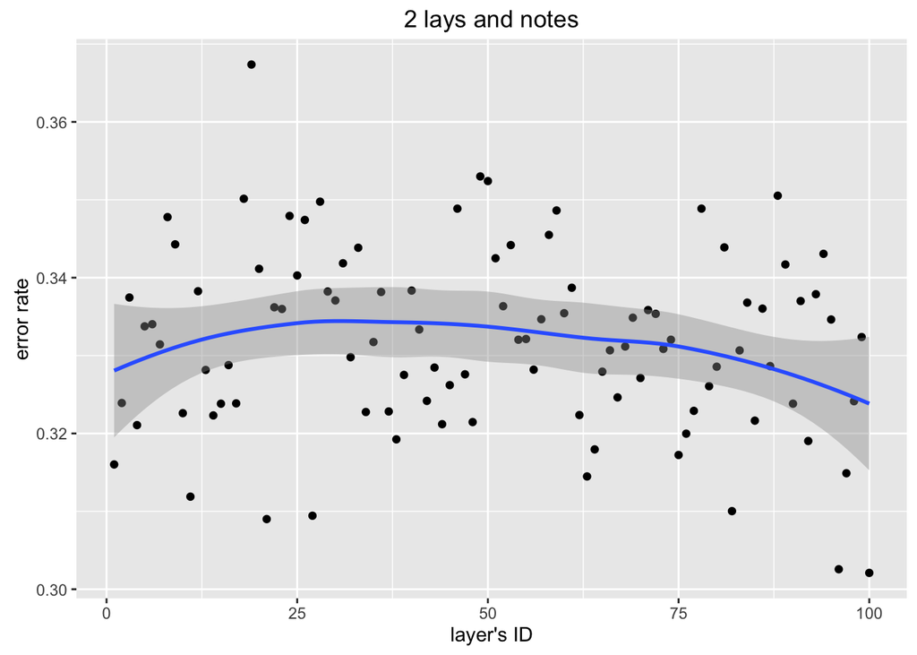

```
## [1] "mean error"        "0.333674166540741"
```

```
## [1] "minimal error" "0.3190361672"
```

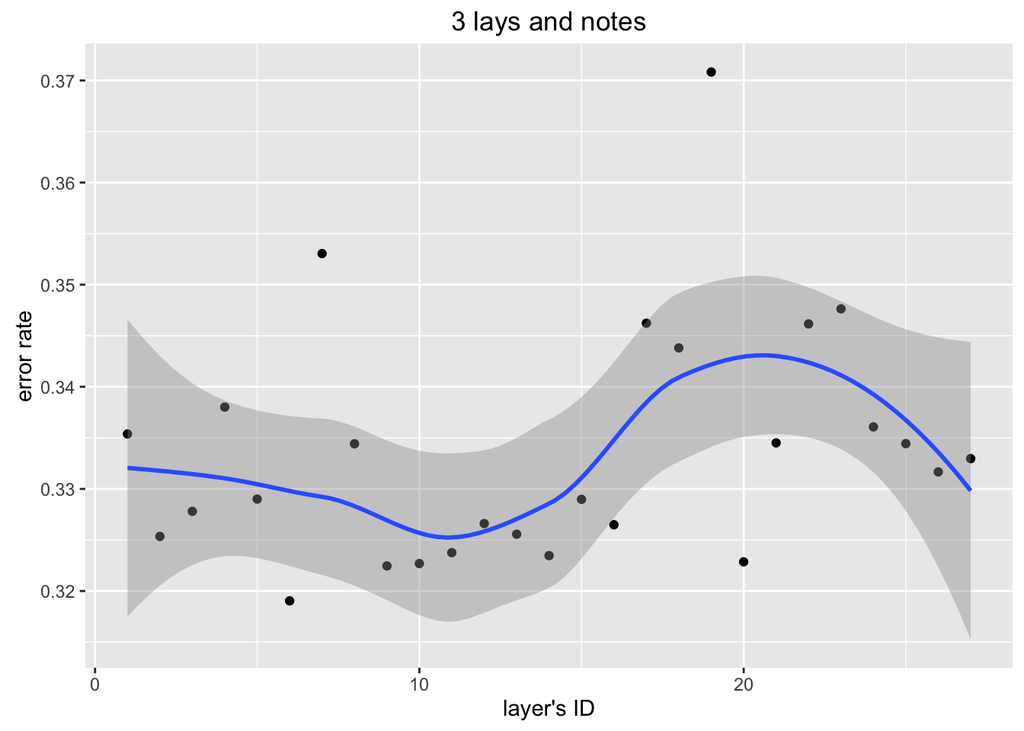

### advance model by switch the model to random forest

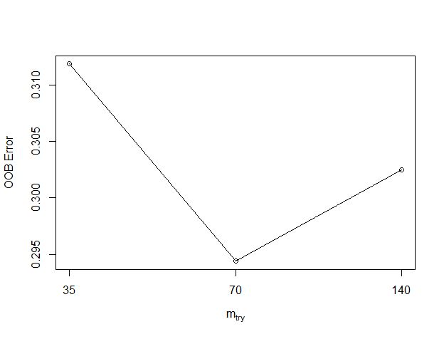

n tree is the times that random forest train, Mtry sometimes needs to base on our data scale. we have 5000 variables in train data, therefore we first tried the square root of 5000, which is around 70

By this picture, we finally choose random forest when mtry=70 as our advanced model.

### advance model by new method to extract features

Focus on: TEXTURE, AND COLOR;

Therefore, we choose the method that combining the rgb, orb, and sift features, then use pca to reduce the dimension as our new features.

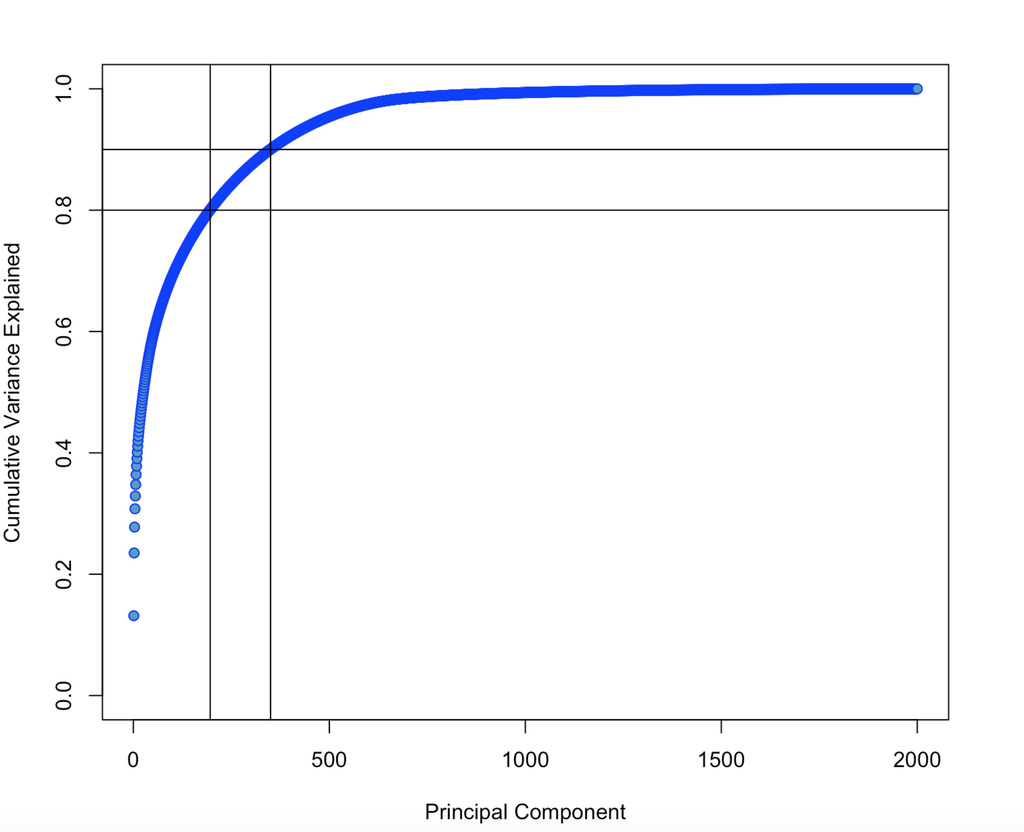

By mofidy this we reduced our error rate to 12.95%, sd is 0.01848